# Analysis of the Death Penalty in the United States

Camilla Bendetti, Anna Bebbington, Maxwell Kent, Dylan Kurzer-Ogul

4/21/2020

## What role do race, gender and region play in the implementation of the death penalty?

[figure not shown]

## Background

The United States is the only country in North America and Europe (excluding Belarus and Russia) in which the death penalty is still legal and actively practiced. In general, the death penalty is thought to be reserved for the most serious crimes. What crimes merit the death penalty varies from state to state, but these offenses generally include premeditated murder, murder with special circumstances (such as killing a police officer or prison guard), rape with additional bodily harm, and treason [(Cornell Law)](https://www.law.cornell.edu/wex/capital_offense) [(LA Times)](https://www.latimes.com/opinion/editorials/la-ed-death-penalty-prop-62-66-20160915-snap-story.html).

Currently 30 states and the federal government have a death penalty statute. However, not all of those states have executed anyone since the death penalty was reinstated in 1976, and a handful of states have gotten rid of the death penalty since then.

However, plenty of states continue to use the death penalty. In fact, in 2016, voters in California, Nebraska, and Oklahoma chose to continue using the death penalty. Californians voted to speed up the death penalty process by limiting appeals, legal challenges to the administration of the death penalty, and expanding the pool of attorneys who can litigate death penalty appeals [(LA Times)](https://www.latimes.com/politics/essential/la-pol-ca-essential-politics-updates-proposition-66-death-penalty-passes-1479869920-htmlstory.html) [(American Bar)](https://www.americanbar.org/groups/committees/death_penalty_representation/project_press/2017/year-end/california-supreme-court-upholds-prop-66/).

## A Hotly Debated Issue

These affirmations of the death penalty come at a time when more legal professionals and voters are denouncing the practice. Washington state’s Supreme Court outlawed the death penalty in October of 2018, because the justices believed that “the death penalty is invalid because it is imposed in an arbitrary and racially biased manner” [(Washington Post)](https://www.washingtonpost.com/news/post-nation/wp/2018/10/11/washington-supreme-court-strikes-down-states-death-penalty-saying-it-is-arbitrary-and-racially-biased/?noredirect=on&utm_term=.8dedeb4c3f41). Even as Californians voted to keep the death penalty, a federal judge in the state ruled that the death penalty was unconstitutional, again citing its arbitrary nature, calling the death penalty “a system in which arbitrary factors, rather than legitimate ones like the nature of the crime or the date of the death sentence, determine whether an individual will actually be executed” [(New York Times)](https://www.nytimes.com/2014/07/17/us/california-death-penalty-unconstitutional-federal-judge-says.html?_r=0&module=inline). In recent years, studies have found significant error in the death penalty [(Death Penalty Information Center)](https://deathpenaltyinfo.org/summary-columbia-university-study-prof-james-s-liebman), and it is estimated that for every nine people executed in this country, “one innocent person [has been] exonerated and released from death row.” [(Ted Talk)](https://www.ted.com/talks/bryan_stevenson_we_need_to_talk_about_an_injustice?language=en). Indeed, authors, activists, and government officials have drawn attention to the dramatic racial inequalities central to the criminal justice system as a whole.

At a time where there are conflicting opinions about the implementation of the death penalty, new insights about the error rates and arbitrary nature of the practice continue to arise. The goal of this project is to grain a better understanding of the death penalty. Specifically, we wanted to investigate the role of race, gender, and region in the implementation of the death penalty in the United States. Our analysis is based on death penalty data collected by the Death Penalty Information Center between 1976 and 2016, downloadable from Kaggle, 2010 Census data on Race, and 2017 racial data, downloadable from the Kaiser Health Foundation.

## Key Rulings

While the death penalty remains very much legal in the US, the courts have continued to rule on and adjust its use. Here are a couple of key rulings:

**Furman v. Georgia (1972)** *The death penalty is ruled unconstitutional*

**Gregg v. Georgia (1976)** *The death penalty is ruled constitutional and reinstated*

**Woodson v. North Carolina (1976)** *Ruling declared that mandatory death sentences violate the 8th and 14th Amendments*

**Roper v. Simmons (2005)** *Courts rule that the constitution prohibits the execution of individuals who were under 18 at the time of their offense*

## Demographics of the Death Penalty

From the plot below, we can see that men are overwhelmingly convicted and administered the death penalty. Since 1976, the year the death penalty was reinstated, and 2016, when the last data was collected, 1,426 men were executed, and only 16 women were executed.

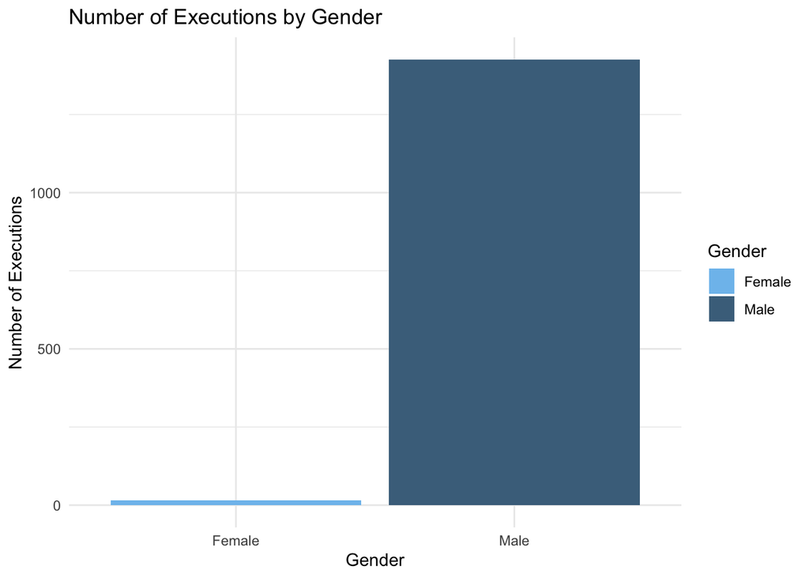

Of those 16 women, 12 women were White and 4 women were Black. There are no women of other races represented in this data.

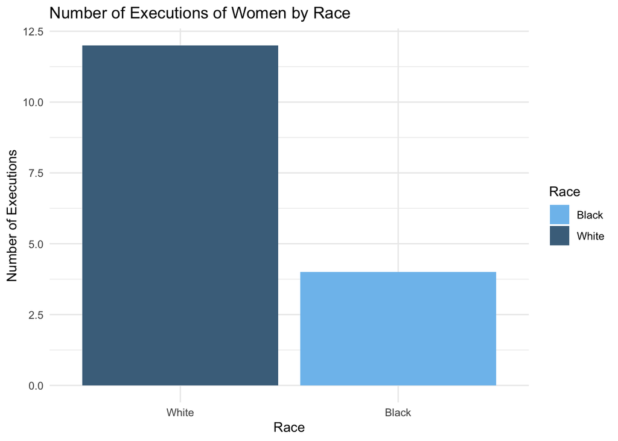

Of the 1,426 men executed, about half of the executions were of White men, followed by Black, Latino, Native American, Asian, and finally men of other races.

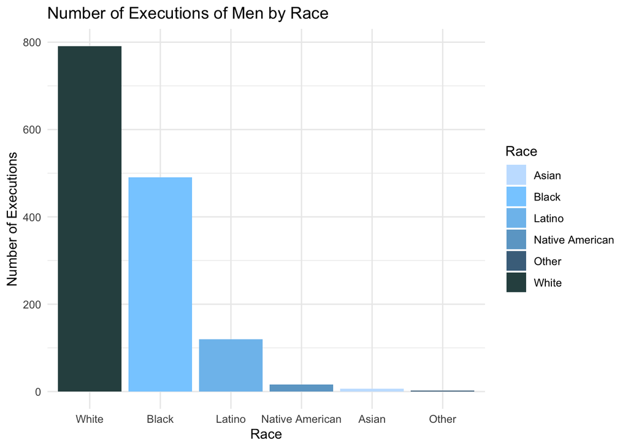

When looking at the age at which prisoners are executed for the three largest populations in this dataset – White, Black, and Latino – we see similar age distributions, with the majority of prisoners executed around age 40. This is potentially explained by the long appeals process, as it can take up to 20 years before inmates are executed. Considering that most violent crime is committed by people between the ages of 16 and 24 [(Bureau of Justice Statistics)](https://www.bjs.gov/content/pub/pdf/VIOCRM.PDF), it is fairly intuitive than that most executions would occur around the age of 40, after the 20-year appeals process. It is noteworthy, however, that the age distribution of for executions of Black inmates is skewed slightly younger. This could potentially be explained by Black prisoners having fewer resources for appeals.

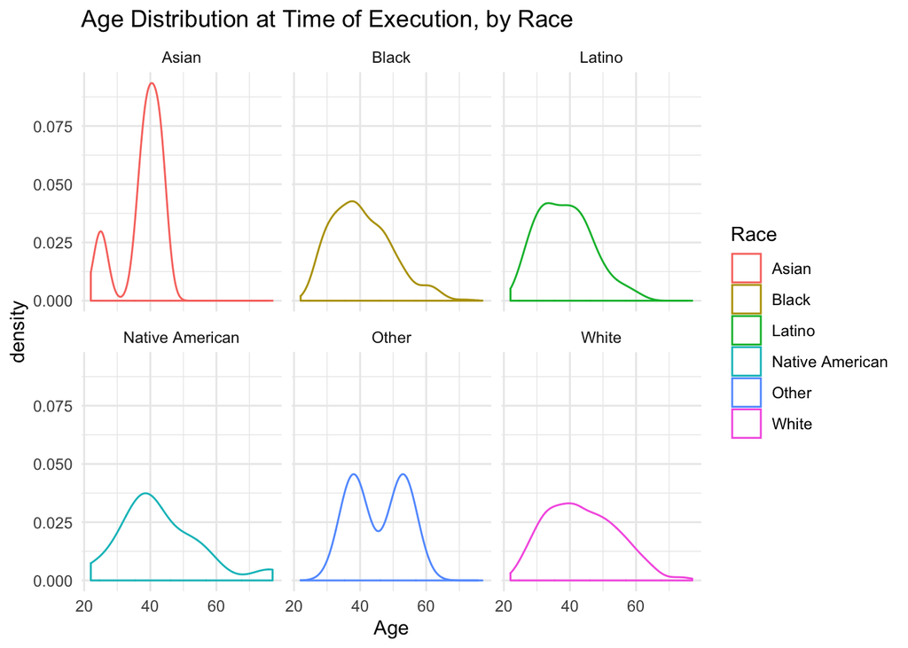

## Trends over time

Since 1976, we see that the trends in executions of White and Black prisoners reflect the total number of executions each year.

[interactive chart not shown]

There is almost exponential growth in the number of executions leading up to 1999 when there were 98 executions. This rapid growth can potentially be explained again by the long appeals process, meaning that people sentenced to the death penalty in the years after it was reinstated were not immediately executed. Since then, the number of executions per year has gradually fallen, though numbers remain high.

## Geographic Trends in the Death Penalty

From the plot below we see certain regional trends in execution. Only White prisoners have been executed in the Northeast, and the Midwest has only executed White, Black, and Native American prisoners. While White prisoners are the majority of those executed in the West, there is more diversity in who is executed, with a large number of Latinos, and more executions of Native Americans and Asians than other regions. Finally, in the South, only around half of the executions are of White prisoners, and the South has the largest number of executions of Black and Latino prisoners

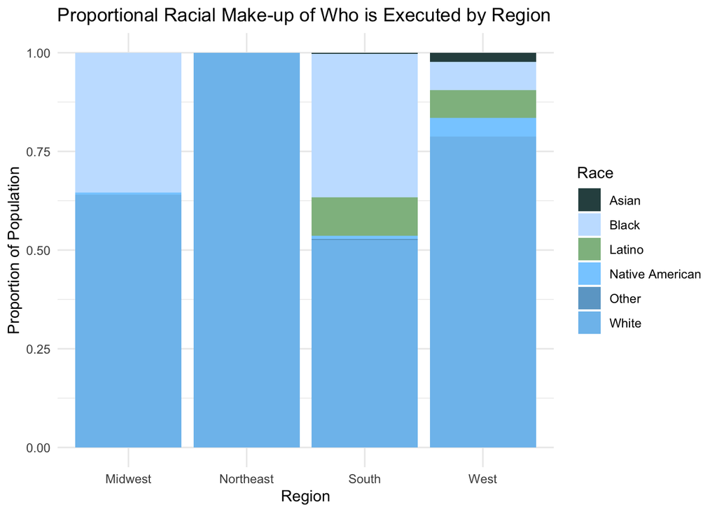

However, we have to keep in mind the size of the data we are working with before drawing any conclusions. Our data set is fairly small, with only 1442 cases , and when these are divided among regions, the data for each region can be too small to be indicative of any strong trends. Additionally, there is significant variation among the number of cases per region. Since 1976, only 4 people have been executed in the entire Northeast, whereas 1,175 people have been executed in the South in the same time period.

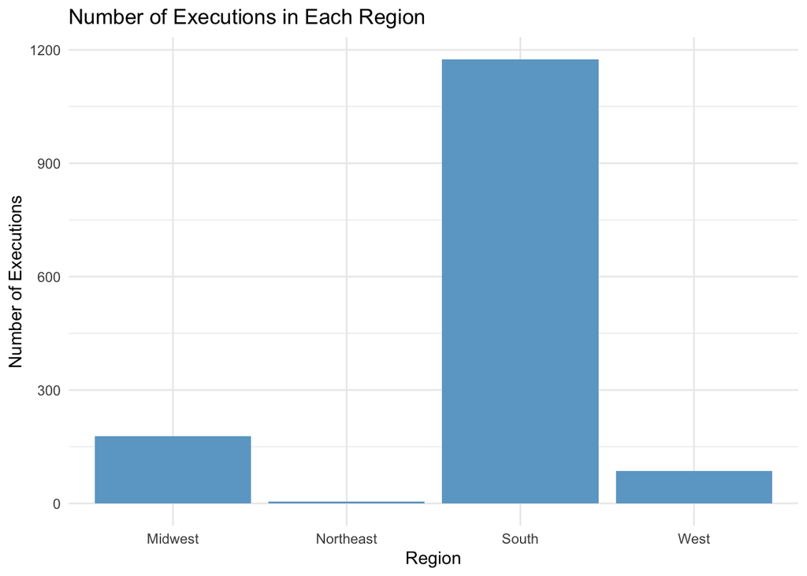

When examining the role of race in the death penalty by region, it is also important to note the racial makeup of each region. The graph below includes population data only of those states with the death penalty, which is why the Northeast has such a small population and the South such a large population.

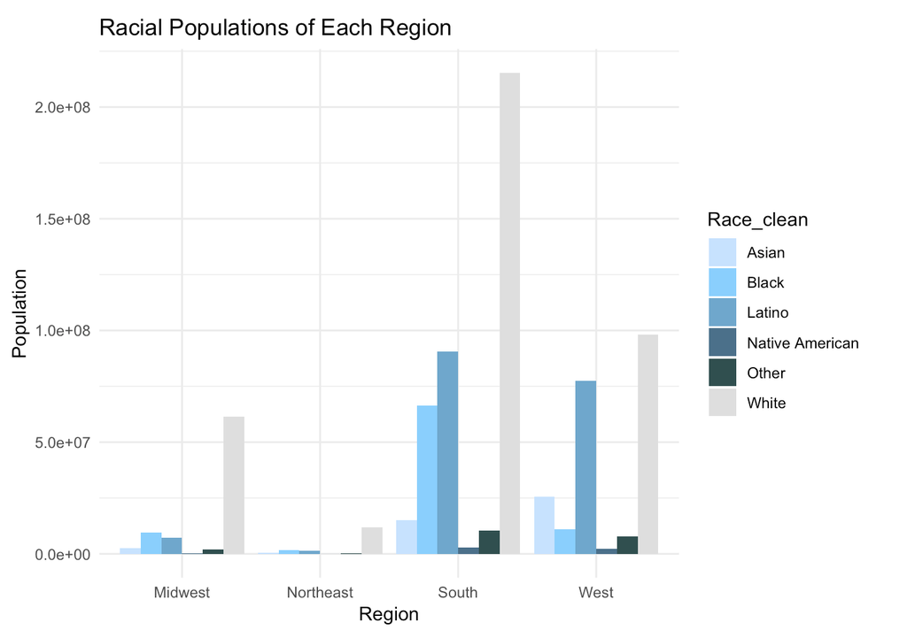

To better understand the racial breakdown of executions in each region, we need to change our original graph so that it takes into account the actual racial populations in each region. The first graph indicated that White prisoners are the most frequently executed, but as White people are the majority across all regions of the United States, this could be due to the population size.

In the graph below, we see the relationship between region and the number of people of a given race executed, divided by the number of people of that race according to 2017 Kaiser Health estimates. This shows how many people of a given racial group are executed relative to their population in the region. The higher bars show that more people of that racial group are executed relative to their population in that region, or that they are overrepresented in their executions.

Native Americans were most overrepresented relative to their population in the Midwest, although this could simply be because there are much fewer Native Americans in the Midwest than there are of any other racial group, as only one Native American was executed in the Midwest in this time period. To some extent, the overrepresentation of Native Americans in the death penalty in the Midwest is most illustrative of the very small population of Native Americans in Midwestern states that have the death penalty.

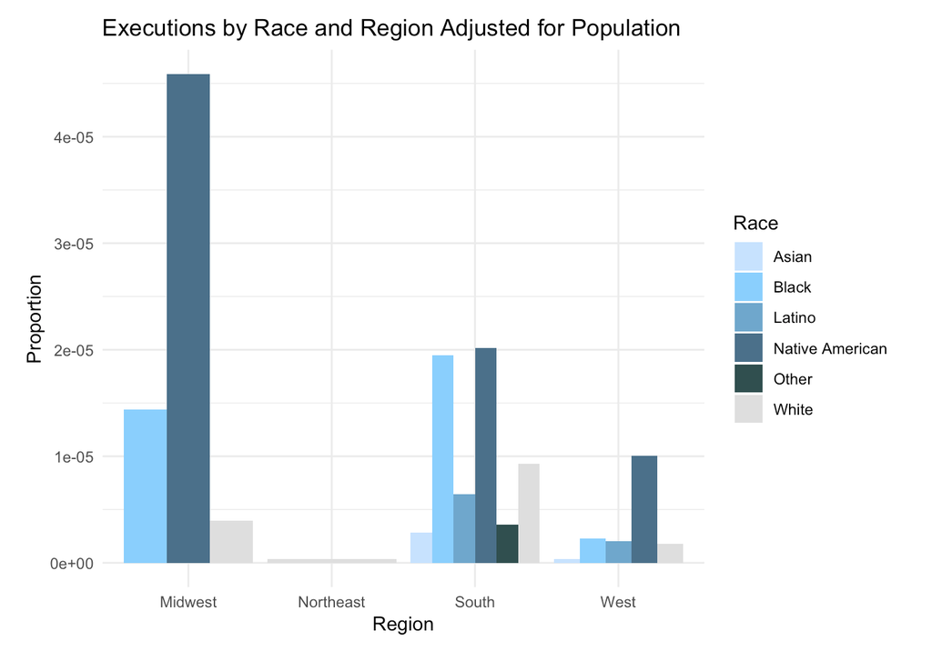

## Mapping Geographic Trends in the Death Penalty

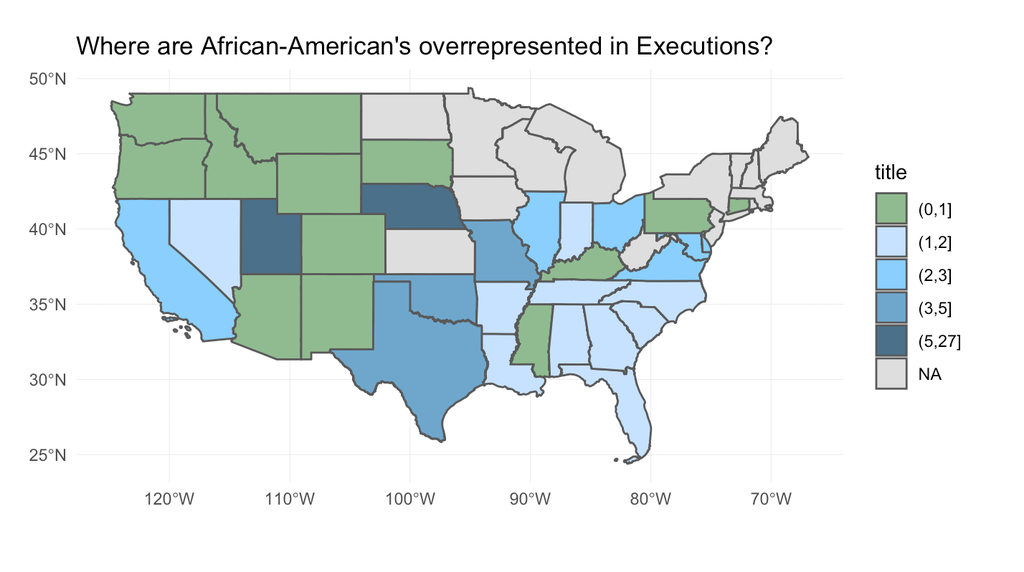

When we look at the ratio of the percentage of executions of Black prisoners per state to the percentage of Black people in a state’s population, we see that most states execute more Black prisoners than is proportional to their population. Eleven states have executed no Black prisoners, and two states have executed fewer Black prisoners than is proportional to their state’s population. In Utah and Nebraska, on the other hand, the number of Black prisoners executed is disproportionate to their population. We can argue, therefore, that Black prisoners are as a rule over-represented in the use of the death penalty.

## Exploring the Race and Gender of the Victims

Are executed prisoners who kill people outside of their racial group more likely to receive the death penalty? Are men who receive the death penalty more likely to kill women? We were curious if the demographics of the victims could provide any explanation to these questions.

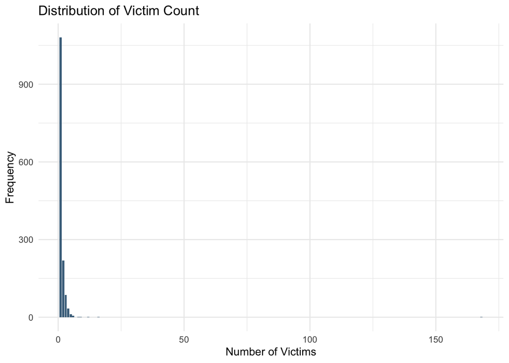

At first glance, we see that the majority of the prisoners only killed 1 person, with the next highest grouping being those who killed 2-3 people, perhaps not surprisingly. There are also some outliers. The highest number of victims is 168, by Timothy McVeigh, the primary perpetrator of the Oklahoma City Bombing.

**But what role does race play?**

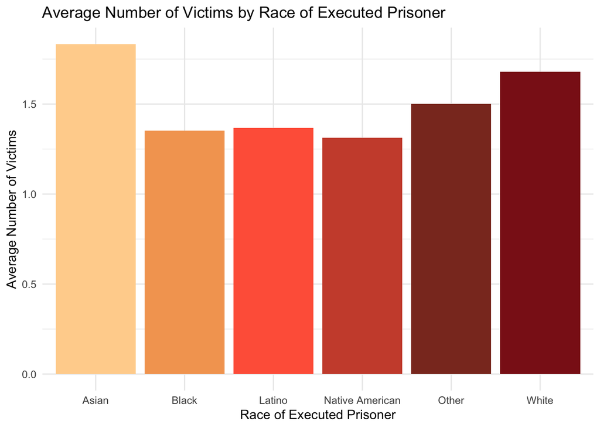

At first glance, this graph shows that Asian and White prisoners have more victims than other groups of executed prisoners.

However, we need to consider that there are significantly fewer Asian and Native American prisoners than any other group of executed prisoners. This means that the average number of victims of those groups can be skewed because of outliers. There is little reason to believe that from our sample you can predict the number of victims from their race.

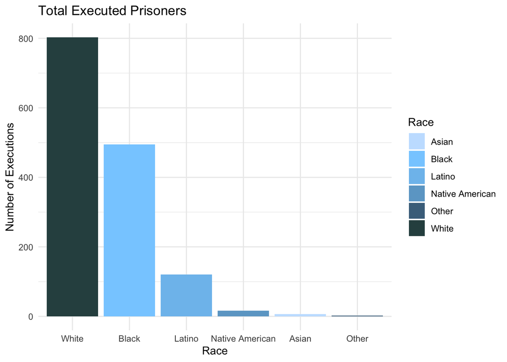

Second, however, in the case of White prisoners, almost the opposite is true. Of all the racial groups, not only are most executed prisoners White, but they also have the second-highest average number of victims. So we asked the question, “Is there a correlation between the race of the executed prisoner and the total number of people they kill, or is there some relationship between the race of the prisoner and the race of the victim?”

[interactive chart not shown]

This graphic reinforces the idea that White prisoners have the most victims each year. Once again, the spike in victims in 2001 is attributed to the execution of Timothy McVeigh in 2001.

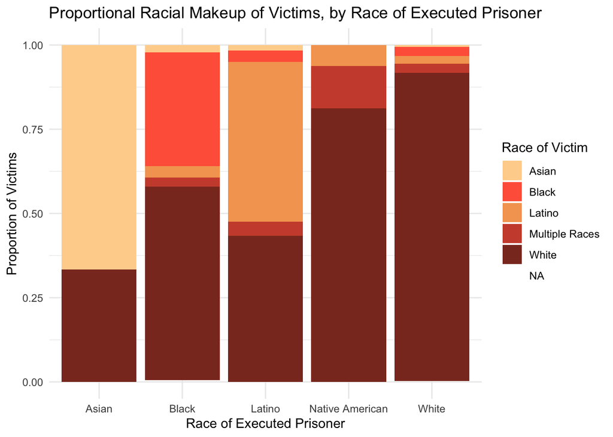

This graph shows that White people make up the largest proportion of victims for all racial groups of prisoners, except for Latino and Asian prisoners.

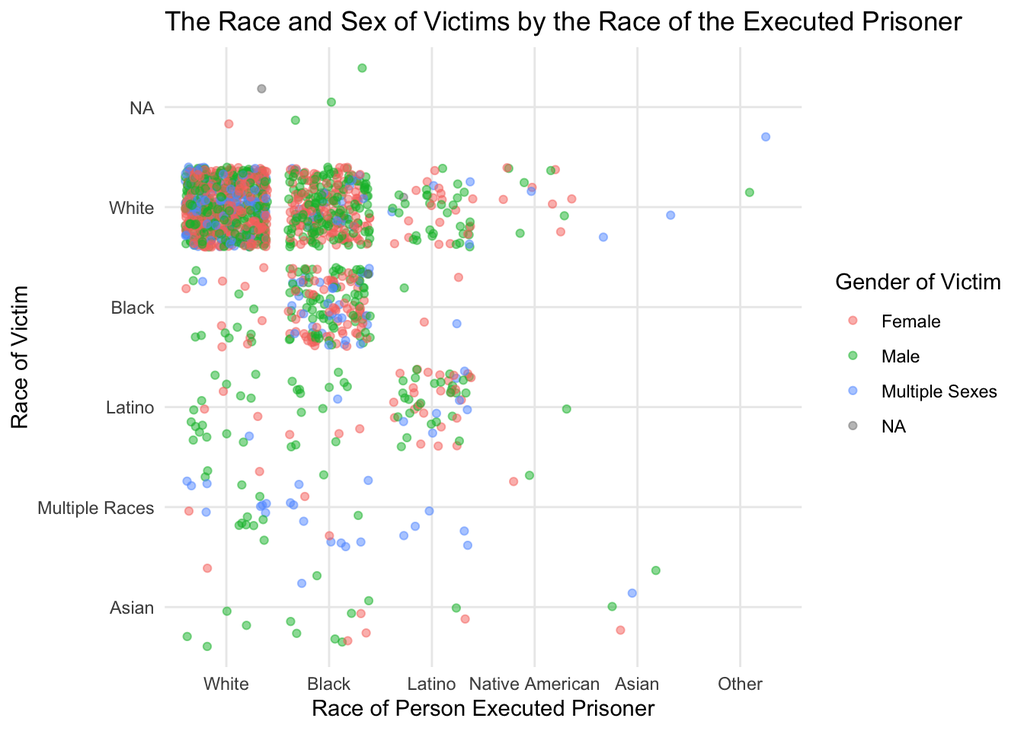

## Conclusions

This data is limited because it does not include those who were put on death row and then had their sentences commuted or died while waiting on death row. We also realize that populations vary by year. We chose to focus on 2010 and 2017 for reasons of data availability, though we are aware that the population is not stagnant. The data represents the date of execution and does not show when the prisoner was sentenced or how long they were kept on death row.

**Gender**: From this data set we can conclude that more men receive the death penalty than women. There are not enough women in our dataset to draw significant conclusions about women who were given the death penalty.